# MongoDB

## Conexión con MongoDB y borrado de datos

```python
import pymongo
from pymongo import MongoClient
from pymongo.errors import DuplicateKeyError
import json

from pprintpp import pprint as pp
```

```python
# connect to database
connection = MongoClient('localhost', 27017)
```

```python
# Borramos la base de datos
connection.drop_database('black')

# Pymongo permite una sintaxis practicamente igual que la original
db = connection.black
```

## Lectura en Pandas

Leemos los datos desde el fichero Excel y los desnormalizamos

```python
import pandas as pd
import datetime
```

```python
df_mov = pd.read_excel("../../data/black.xlsx", sheet_name= "Movimientos", engine='openpyxl')
df_miembros = pd.read_excel("../../data/black.xlsx", sheet_name= "Miembros", engine='openpyxl')
df = pd.merge(df_mov, df_miembros, on = ['id_miembro'], how = 'inner')
df.info()
```

```
<class 'pandas.core.frame.DataFrame'>
Int64Index: 7624 entries, 0 to 7623
Data columns (total 11 columns):
 #   Column              Non-Null Count  Dtype
---  ------              --------------  -----
 0   id_miembro          7624 non-null   int64
 1   fecha               7624 non-null   datetime64[ns]
 2   hora                7624 non-null   int64
 3   minuto              7624 non-null   int64
 4   importe             7624 non-null   float64
 5   comercio            6882 non-null   object
 6   actividad_completa  7621 non-null   object
 7   actividad           7621 non-null   object
 8   nombre              7624 non-null   object
 9   funcion             7624 non-null   object
 10  organizacion        6060 non-null   object
dtypes: datetime64[ns](1), float64(1), int64(3), object(6)
memory usage: 714.8+ KB
```

## Carga en MongoDB

Gracias a Pandas convertimos el dataset en formato JSON, que es el que vamos a insertar en MongoDB prácticamente sin cambios.

```python
json_string = df.to_json(orient = 'records')
json_list = json.loads(json_string)
```

```python
pp(json_list[0])
```

```
{
    'actividad': 'SALUD',
    'actividad_completa': 'FARMACIAS',
    'comercio': 'FCIA TORRES MU¬OZ',
    'fecha': 1145232000000,
    'funcion': 'concejal',
    'hora': 11,
    'id_miembro': 77,
    'importe': 44.56,
    'minuto': 40,
    'nombre': 'Ricardo Romero de Tejada y Picatoste',
    'organizacion': 'Partido Popular',
}
```

En MongoDB vamos a crear una única colección donde vamos a guardar todos los datos desnormalizados:

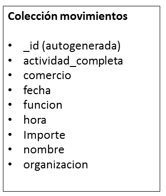

En la inserción de la información en mongo realizan algunas tareas de limpieza:

- Eliminar los campos nulos (no todos)
- Convertir la fecha a un formato DateTime, de forma que mongo inserte el dato correctamente
- Eliminar campos que no queremos tener en el modelo (id_miembro)

```python
for movimiento_json in json_list:
    movimiento_json['fecha'] = datetime.datetime.fromtimestamp(movimiento_json['fecha'] / 1e3)

    del movimiento_json['id_miembro']

    if  movimiento_json['comercio'] == None:
        del movimiento_json['comercio']

    db.movimientos.insert_one(movimiento_json)
```

## Querys

Todas las querys de este caso de uso se pueden resolver directamente por la base de datos ...

### Los 10 movimientos mas caros

```python
rs = db.movimientos.find({}, {
    "nombre": 1,
    "fecha": 1,
    "actividad_completa": 1,
    "importe": 1,
    "_id" : 0
}).limit(10).sort([("importe", -1)])
```

```python
pd.DataFrame(list(rs))
```

|  | fecha | importe | actividad_completa | nombre |
| --- | --- | --- | --- | --- |
| 0 | 2007-11-28 | 12000.00 | AGENCIAS BANCARIAS(ANTICIPO VENTANILLA) | Enrique de la Torre Martínez |
| 1 | 2007-12-19 | 9424.08 | AGENCIAS BANCARIAS(ANTICIPO VENTANILLA) | Ramón Ferraz Ricarte |
| 2 | 2008-10-23 | 9000.00 | AGENCIAS BANCARIAS(ANTICIPO VENTANILLA) | Enrique de la Torre Martínez |
| 3 | 2006-11-29 | 8000.00 | AGENCIAS BANCARIAS(ANTICIPO VENTANILLA) | Enrique de la Torre Martínez |
| 4 | 2006-12-26 | 6397.31 | EL CORTE INGLES | Miguel Blesa de la Parra |
| 5 | 2007-11-30 | 6375.00 | CONFECCION TEXTIL EN GENERAL | Rafael Spottorno Díaz Caro |
| 6 | 2006-08-13 | 6198.02 | HOTELES 4 Y 5 ESTRELLAS,BALNEARIOS,CAMPI | Carmen Contreras Gómez |
| 7 | 2006-08-13 | 5763.10 | BRITISH AIRWAYS - BRITISH A | Matías Amat Roca |
| 8 | 2005-07-31 | 5403.97 | AUTOM.Y MOTOCICLETAS ( VENTAS Y REPARAC) | Juan Manuel Astorqui Portera |
| 9 | 2004-12-06 | 5390.00 | AGENCIAS BANCARIAS(ANTICIPO VENTANILLA) | Enrique de la Torre Martínez |

### Los 10 movimientos mas caros por actividad

```python
rs = db.movimientos.find({
    "actividad": "HOGAR"
}, {
    "nombre": 1,
    "fecha": 1,
    "actividad_completa": 1,
    "importe": 1,
    "_id" : 0
}).limit(10).sort([("importe", -1)])
```

```python
pd.DataFrame(list(rs))
```

|  | fecha | importe | actividad_completa | nombre |
| --- | --- | --- | --- | --- |
| 0 | 2007-10-14 | 2150.00 | MUEBLES,ANTIGUEDADES Y GALERIAS DE ARTE | Miguel Ángel Araujo Serrano |
| 1 | 2005-12-16 | 1908.19 | FLORES Y PLANTAS | Mariano Pérez Claver |
| 2 | 2004-01-09 | 1800.00 | TAPICERIAS,ALFOMBRAS | Domingo Navalmoral Sánchez |
| 3 | 2008-07-06 | 1281.31 | MUEBLES,ANTIGUEDADES Y GALERIAS DE ARTE | Ramón Ferraz Ricarte |
| 4 | 2011-03-10 | 1231.00 | MUEBLES DE COCINA | Miguel Ángel Araujo Serrano |
| 5 | 2007-04-20 | 1188.90 | MUEBLES,ANTIGUEDADES Y GALERIAS DE ARTE | Francisco Baquero Noriega |
| 6 | 2006-11-03 | 1090.00 | MUEBLES,ANTIGUEDADES Y GALERIAS DE ARTE | Francisco Baquero Noriega |
| 7 | 2011-05-24 | 1000.00 | MUEBLES,ANTIGUEDADES Y GALERIAS DE ARTE | Jesús Pedroche Nieto |
| 8 | 2009-04-06 | 1000.00 | ELECTRODOMESTICOS,EQUIPOS ELECTRICOS | Ricardo Romero de Tejada y Picatoste |
| 9 | 2006-02-07 | 1000.00 | MUEBLES,ANTIGUEDADES Y GALERIAS DE ARTE | Pedro Bugidos Garay |

### Las 10 personas que mas han gastado

En este caso, al obtener un dato agregado, necesitamos utilizar la función **aggregate()** de mongo

```python
rs = db.movimientos.aggregate([
        {"$group" : { "_id" : "$nombre", "importe" : { "$sum" : "$importe"}}},
        {"$sort" : {"importe" : -1}},
        {"$limit" : 10},
        {"$project" : {"_id" : 0, "nombre": "$_id", "importe": 1}}
    ])
```

```python
df = pd.DataFrame(list(rs))
df
```

|  | importe | nombre |
| --- | --- | --- |
| 0 | 58826.28 | Enrique de la Torre Martínez |
| 1 | 52447.07 | José Antonio Moral Santín |
| 2 | 45371.52 | Ramón Ferraz Ricarte |
| 3 | 40298.84 | Miguel Blesa de la Parra |
| 4 | 39437.99 | Ildefonso José Sánchez Barcoj |
| 5 | 36627.89 | Juan Manuel Astorqui Portera |
| 6 | 35256.67 | Francisco Baquero Noriega |
| 7 | 33434.74 | Matías Amat Roca |
| 8 | 31556.45 | Carmen Contreras Gómez |
| 9 | 29350.65 | Estanislao Rodríguez-Ponga Salamanca |

### ¿Que comercio es más popular?

Este es un caso especial de agregación, ya que cuenta los distintos. Dentro del flujo de la función se realizan varios pasos para resolver esta query:

- Formar un conjunto con los distintas personas que han comprado en cada comercio
- Desagregar el conjunto
- Agrupar los comercios, contanto los distintos elementos de cada conjunto

```python
rs = db.movimientos.aggregate([
        {"$group" : { "_id" : "$comercio", "nombres" : { "$addToSet" : "$nombre"}}},
        {"$unwind" : "$nombres"},
        {"$group" : { "_id" : "$_id", "cuenta" : { "$sum" : 1}}},
        {"$sort" : {"cuenta" : -1}},
        {"$project" : {"_id" : 0, "comercio": "$_id", "cuenta": 1}},
        {"$match": {"comercio": { "$exists": True, "$ne": None }}},
        {"$limit" : 10}
    ])
```

```python
df = pd.DataFrame(list(rs))
df
```

|  | cuenta | comercio |
| --- | --- | --- |
| 0 | 49 | EL CORTE INGLES |
| 1 | 29 | IBERIA |
| 2 | 28 | RENFE 001 |
| 3 | 26 | EL CORTE INGLES S.A. |
| 4 | 16 | PARKING EGUISA C/SEVILLA |
| 5 | 15 | VIAJES ECI |
| 6 | 14 | ESPASA CALPE-CASA DEL LIBRO |
| 7 | 13 | ACCESOS DE MADRID |
| 8 | 13 | REST EL ESPIGON |
| 9 | 13 | APARCAMIENTO CORTES |

Truco ...

En este tipo de querys complicadas podemos ver los resultados parciales ...

```python
rs = db.movimientos.aggregate([
        {"$group" : { "_id" : "$comercio", "nombres" : { "$addToSet" : "$nombre"}}},
        {"$unwind" : "$nombres"}
    ])

pd.DataFrame(list(rs)).head()
```

|  | _id | nombres |
| --- | --- | --- |
| 0 | MORALEJA NAILS | Ignacio de Navasques Cobián |
| 1 | BUFFALO GRILL ESPA/A S.A. | Antonio Romero Lázaro |
| 2 | OPAZO | Maria Mercedes de la Merced Monge |
| 3 | AUTOPISTAS DE NAVARRA S.A. | Gonzalo Martín Pascual |
| 4 | AUTOPISTAS DE NAVARRA S.A. | Juan Manuel Astorqui Portera |